# Homework 2

# Introduction

In this analysis, we will apply supervised learning tools for both classification and advanced regression. To do this, we will use a dataset which documents the factors affecting the agricultural yield of a piece of land, such as rain, irrigation, fertilization, etc.

We will use the agricultural yield as both a categorical and a numerical target variable, dividing it into high and low yield for the classification.

# Data preprocessing

## Load the data

```r
rm(list=ls()) # delete all previous data on the environment
training = read.csv("agricultural_yield_train.csv")
testing = read.csv("agricultural_yield_test.csv")

set.seed(123) # We set the seed to obtain consistent results
```

## Libraries

We load all the libraries needed for this project.

```r
library(tidyverse)
library(skimr)
library(mice)
library(VIM)
library(GGally)
library(MASS)
library(glmnet)
library(e1071)
library(rpart)
library(pROC)
library(class)
library(randomForest)
library(caret)
library(fastDummies)
```

## Feature engineering

At first, we thought about changing the seed variety variable (a numerical variable where 1 is a high yield seed variety and 0 a low yield seed variety) into a factor variable. However, this stops us from being able to use ggcorr() and seeing its relationship with the target variable, so we decided against it.

```r
# We use the median as a threshold for a new variable called Yield which will be used for the classification. This variable will have two levels, high and low to allow glm classification.

# We create separate training / testing datasets for the classification and the regression.

trainingCls = training
testingCls = testing

# We calculate the median using both the training and testing sets.
med = (4*median(training$Yield_kg_per_hectare) + median(testing$Yield_kg_per_hectare))/ 5

trainingCls$Yield = as.factor(ifelse(trainingCls[["Yield_kg_per_hectare"]] > med, "High", "Low"))
testingCls$Yield = as.factor(ifelse(testingCls[["Yield_kg_per_hectare"]] > med, "High", "Low"))

trainingCls <- trainingCls %>%  dplyr::select(-Yield_kg_per_hectare)
testingCls <- testingCls %>%  dplyr::select(-Yield_kg_per_hectare)
```

## NA

We check if there are NA values.

```r
which(is.na(training), arr.ind=TRUE)
```

```
     row col
```

```r
which(is.na(testing), arr.ind=TRUE)
```

```
     row col
```

There are no NA values.

# Visualization

We will use a correlation table to see the relations between the different variables:

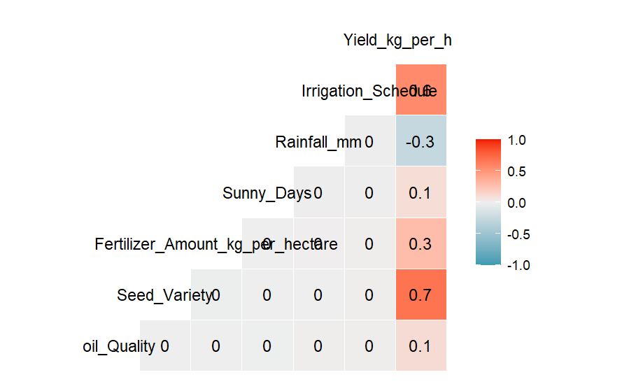

```r
ggcorr(training, label = T)
```

As we can see, the most important variables are seed variety and the irrigation schedule, while soil quality and the number of sunny days are far less important. We can also see that none of the variables that we will use to predict the yield have any correlation with each other, meaning that it will be futile to try to combine them into other variables to thus improve the performance of any model.

Let’s plot the different variables for the classification:

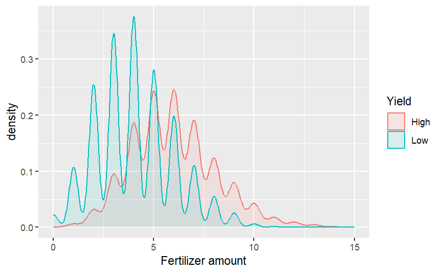

```r
# Numeric vs categorical plot:
ggplot(trainingCls, aes(Irrigation_Schedule)) + geom_density(aes(group=Yield, colour=Yield, fill=Yield), alpha=0.1) +xlab("Fertilizer amount")
```

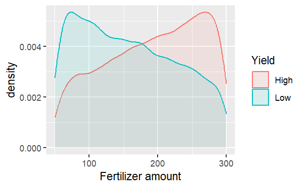

[figure not shown]

```r
ggplot(trainingCls, aes(Fertilizer_Amount_kg_per_hectare)) + geom_density(aes(group=Yield, colour=Yield, fill=Yield), alpha=0.1) +xlab("Fertilizer amount")
```

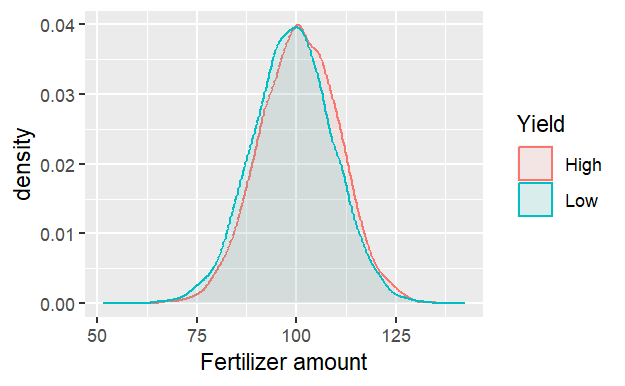

```r
ggplot(trainingCls, aes(Sunny_Days)) + geom_density(aes(group=Yield, colour=Yield, fill=Yield), alpha=0.1) +xlab("Fertilizer amount") # The distributions are almost the same.
```

And for the regression:

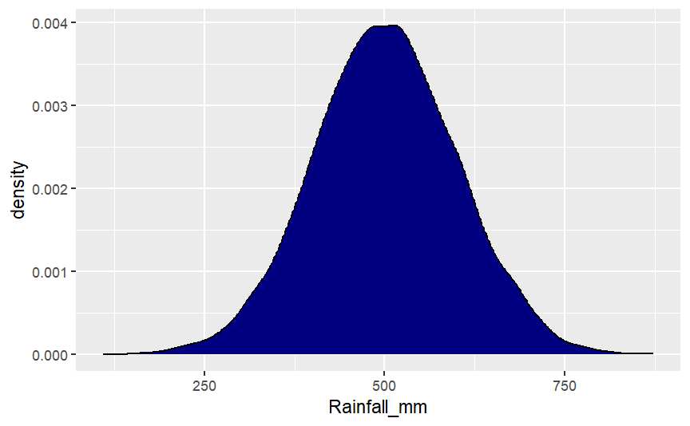

```r
training %>% ggplot(aes(x=Rainfall_mm)) + geom_density(fill="navyblue")
```

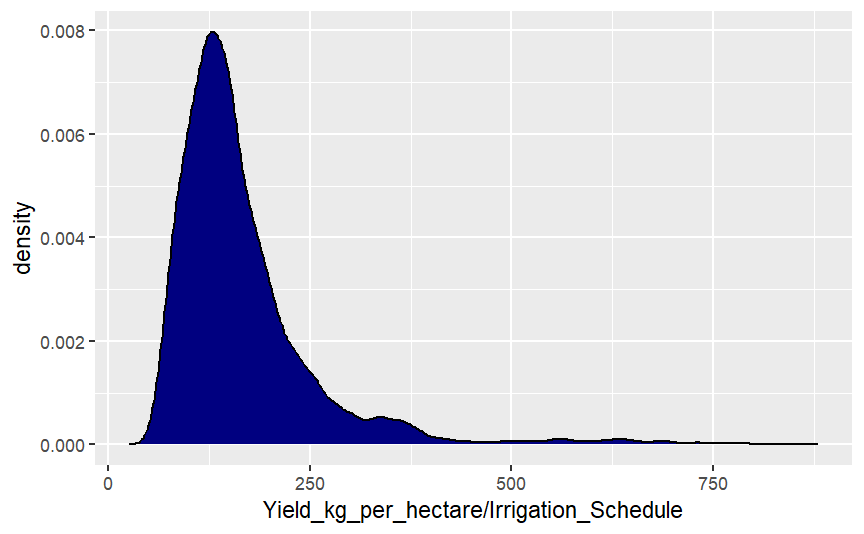

```r
training %>% ggplot(aes(x=Yield_kg_per_hectare/Irrigation_Schedule)) + geom_density(fill="navyblue") # Not much variance, indicating a linear relationship
```

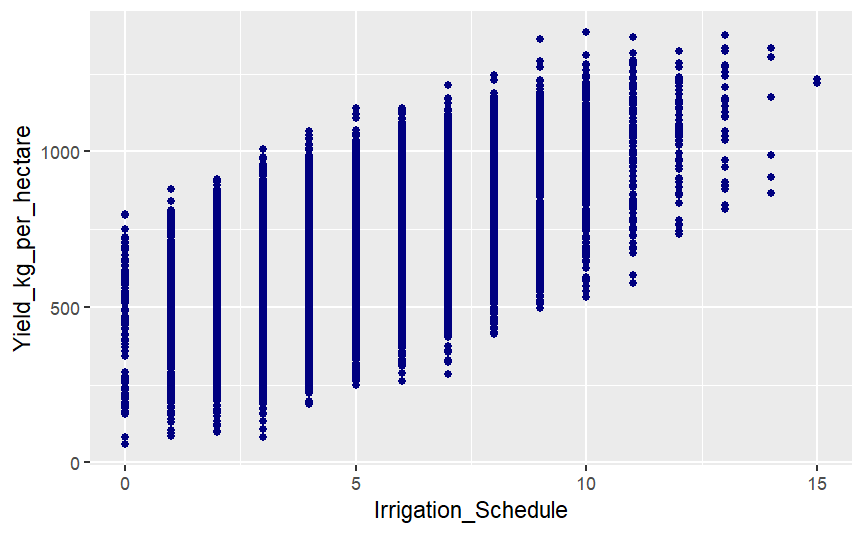

```r
training %>% ggplot(aes(x=Irrigation_Schedule, y=Yield_kg_per_hectare)) + geom_point(color="navyblue")
```

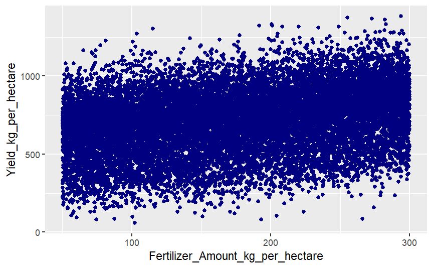

```r
training %>% ggplot(aes(x=Fertilizer_Amount_kg_per_hectare, y=Yield_kg_per_hectare)) + geom_point(color="navyblue")
```

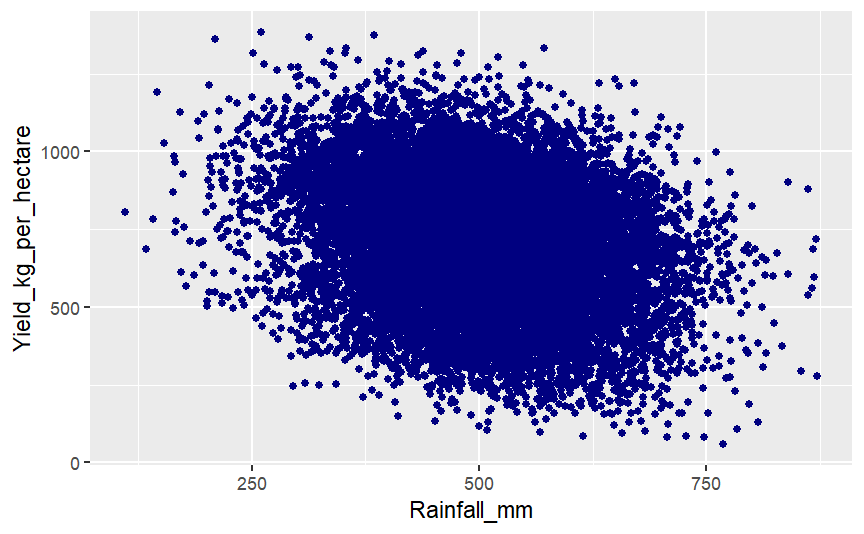

```r
training %>% ggplot(aes(x=Rainfall_mm, y=Yield_kg_per_hectare)) + geom_point(color="navyblue") # Negative slope
```

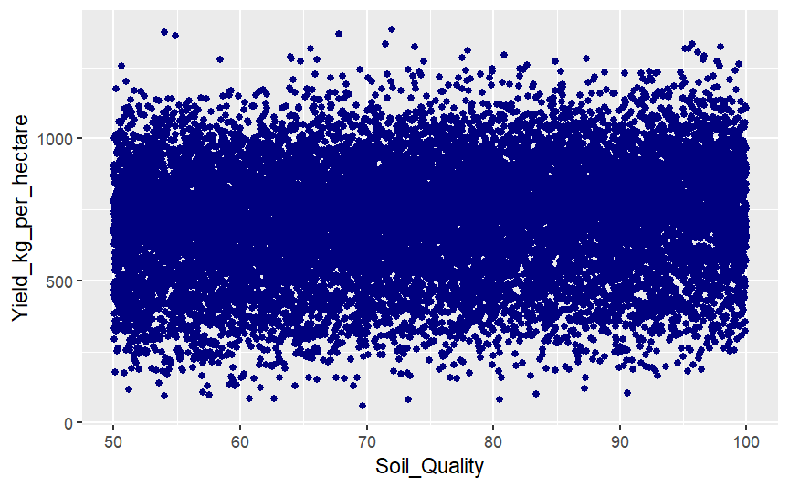

```r
training %>% ggplot(aes(x=Soil_Quality, y=Yield_kg_per_hectare)) + geom_point(color="navyblue") # Barely any correlation, too much noise
```

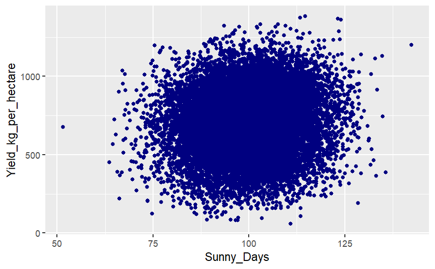

```r
training %>% ggplot(aes(x=Sunny_Days, y=Yield_kg_per_hectare)) + geom_point(color="navyblue") # Barely any correlation, too much noise
```

# Classification

## Bayes Classifiers

For the classification, we are going to start with the Bayes classifiers LDA and QDA, which we are going to compare to each other to obtain the best model which maximizes the accuracy. Our measure of success will be the accuracy, since by default it takes into account both false negatives and true positives unlike the specificity and sensitivity.

### LDA

```r
lda.model <- lda(Yield ~ ., data=trainingCls)

probability_lda = predict(lda.model, newdata=testingCls)$posterior

prediction_lda = predict(lda.model, newdata=testingCls)$class
head(probability_lda)
```

```
          High          Low
1 0.0005088908 0.9994911092
2 0.9664570442 0.0335429558
3 0.8299859466 0.1700140534
4 0.9573437546 0.0426562454
5 0.9990174727 0.0009825273
6 0.9975477535 0.0024522465
```

Performance:

```r
confusionMatrix(prediction_lda, testingCls$Yield)$table
```

```
          Reference
Prediction High  Low
      High 1860  270
      Low    89 1781
```

```r
# Accuracy
confusionMatrix(prediction_lda, testingCls$Yield)$overall[1]
```

```
Accuracy
 0.91025
```

### QDA

```r
qda.model <- qda(Yield ~ ., data=trainingCls)

probability_qda = predict(qda.model, newdata=testingCls)$posterior

prediction_qda = predict(qda.model, newdata=testingCls)$class

head(probability_qda)
```

```
          High          Low
1 3.666346e-08 0.9999999633
2 9.823580e-01 0.0176419646
3 8.736631e-01 0.1263369092
4 9.635140e-01 0.0364859608
5 9.996566e-01 0.0003434225
6 9.986001e-01 0.0013998892
```

Performance:

```r
confusionMatrix(prediction_qda, testingCls$Yield)$table
```

```
          Reference
Prediction High  Low
      High 1836  378
      Low   113 1673
```

```r
# Accuracy
confusionMatrix(prediction_qda, testingCls$Yield)$overall[1]
```

```
Accuracy
 0.87725
```

As we can see, the LDA model is more accurate, with an accuracy slightly above 90%. Nonetheless, we will try other models to see if they are better.

## Logistic regression

Because we have binary classification, we can use the standard glm function in R:

```r
logit.model <- glm(Yield ~ ., family=binomial(link='logit'), data=trainingCls)
summary(logit.model)
```

```
Call:
glm(formula = Yield ~ ., family = binomial(link = "logit"), data = trainingCls)

Coefficients:
                                   Estimate Std. Error z value Pr(>|z|)
(Intercept)                       2.331e+01  6.122e-01   38.08   <2e-16 ***
Soil_Quality                     -5.493e-02  2.485e-03  -22.10   <2e-16 ***
Seed_Variety                     -1.046e+01  2.125e-01  -49.21   <2e-16 ***
Fertilizer_Amount_kg_per_hectare -2.765e-02  6.836e-04  -40.45   <2e-16 ***
Sunny_Days                       -7.137e-02  3.590e-03  -19.88   <2e-16 ***
Rainfall_mm                       1.861e-02  4.823e-04   38.58   <2e-16 ***
Irrigation_Schedule              -1.731e+00  3.582e-02  -48.32   <2e-16 ***
---
Signif. codes:  0 ‘***’ 0.001 ‘**’ 0.01 ‘*’ 0.05 ‘.’ 0.1 ‘ ’ 1

(Dispersion parameter for binomial family taken to be 1)

    Null deviance: 22180.3  on 15999  degrees of freedom
Residual deviance:  5883.8  on 15993  degrees of freedom
AIC: 5897.8

Number of Fisher Scoring iterations: 8
```

Predictions:

```r
probability <- predict(logit.model,newdata=testingCls, type='response')
head(probability)
```

```
           1            2            3            4            5            6
9.999988e-01 3.851417e-03 1.214427e-01 7.883967e-03 7.373479e-06 4.713649e-05
```

```r
prediction <- as.factor(ifelse(probability > 0.5,"Low","High"))
head(prediction)
```

```
   1    2    3    4    5    6
 Low High High High High High
Levels: High Low
```

Performance:

```r
confusionMatrix(prediction, testingCls$Yield)
```

```
Confusion Matrix and Statistics

          Reference
Prediction High  Low
      High 1793  179
      Low   156 1872

               Accuracy : 0.9162
                 95% CI : (0.9072, 0.9247)
    No Information Rate : 0.5128
    P-Value [Acc > NIR] : <2e-16

                  Kappa : 0.8324

 Mcnemar's Test P-Value : 0.2294

            Sensitivity : 0.9200
            Specificity : 0.9127
         Pos Pred Value : 0.9092
         Neg Pred Value : 0.9231
             Prevalence : 0.4873
         Detection Rate : 0.4482
   Detection Prevalence : 0.4930
      Balanced Accuracy : 0.9163

       'Positive' Class : High
```

The value for the accuracy is very slightly higher than that of the LDA, so we will use it for the moment. Note the previous threshold=0.5 is a hyper-parameter which we will try to optimize.

## Penalized logistic regression

When there is a high number of dimensions, it is better to use a penalized version with glmnet.

```r
logit.model <- glmnet(as.matrix(trainingCls),trainingCls$Yield, family=c("binomial"), alpha=0, lambda=0.01)
probability <- predict(logit.model,as.matrix(testingCls), type='response')
prediction <- as.factor(ifelse(probability > 0.5,"Low","High"))

confusionMatrix(prediction, testingCls$Yield)
```

```
Confusion Matrix and Statistics

          Reference
Prediction High  Low
      High 1808  195
      Low   141 1856

               Accuracy : 0.916
                 95% CI : (0.907, 0.9244)
    No Information Rate : 0.5128
    P-Value [Acc > NIR] : < 2.2e-16

                  Kappa : 0.832

 Mcnemar's Test P-Value : 0.003835

            Sensitivity : 0.9277
            Specificity : 0.9049
         Pos Pred Value : 0.9026
         Neg Pred Value : 0.9294
             Prevalence : 0.4873
         Detection Rate : 0.4520
   Detection Prevalence : 0.5008
      Balanced Accuracy : 0.9163

       'Positive' Class : High
```

### Variable importance

We can use another method for penalized regression, which allows us to see the importance of each variable, however, since it does not improve the accuracy compared to a normal logistic regression model, we will not use it for anything else.

```r
ctrl <- trainControl(method = "cv", number = 5,
                     classProbs = TRUE,
                     verboseIter=T)

lrFit <- train(Yield ~ .,
               method = "glmnet",
               tuneGrid = expand.grid(alpha = seq(0, 1, 0.1), lambda = seq(0, .1, 0.02)),
               metric = "Kappa",
               data = trainingCls,
               preProcess = c("center", "scale"),
               trControl = ctrl)
print(lrFit)
```

```
glmnet

16000 samples
    6 predictor
    2 classes: 'High', 'Low'

Pre-processing: centered (6), scaled (6)
Resampling: Cross-Validated (5 fold)
Summary of sample sizes: 12801, 12800, 12799, 12800, 12800
Resampling results across tuning parameters:

  alpha  lambda  Accuracy   Kappa
  0.0    0.00    0.9165002  0.8329668
  0.0    0.02    0.9165002  0.8329668
  0.0    0.04    0.9167502  0.8334627
  0.0    0.06    0.9169378  0.8338308
  0.0    0.08    0.9163127  0.8325750
  0.0    0.10    0.9158126  0.8315718
  0.1    0.00    0.9168125  0.8336130
  0.1    0.02    0.9165002  0.8329708
  0.1    0.04    0.9163127  0.8325869
  0.1    0.06    0.9156877  0.8313281
  0.1    0.08    0.9141875  0.8283216
  0.1    0.10    0.9132501  0.8264404
  0.2    0.00    0.9166875  0.8333632
  0.2    0.02    0.9167500  0.8334717
  0.2    0.04    0.9158750  0.8317097
  0.2    0.06    0.9140627  0.8280754
  0.2    0.08    0.9122501  0.8244390
  0.2    0.10    0.9101874  0.8203060
  0.3    0.00    0.9166875  0.8333634
  0.3    0.02    0.9165002  0.8329703
  0.3    0.04    0.9146251  0.8292070
  0.3    0.06    0.9126250  0.8251952
  0.3    0.08    0.9090624  0.8180578
  0.3    0.10    0.9044373  0.8087927
  0.4    0.00    0.9166875  0.8333634
  0.4    0.02    0.9153751  0.8307189
  0.4    0.04    0.9140625  0.8280799
  0.4    0.06    0.9101875  0.8203147
```

[output cut: 26 more lines]

```
  0.9    0.00    0.9166875  0.8333634
  0.9    0.02    0.9138750  0.8277144
  0.9    0.04    0.9026872  0.8053132
  0.9    0.06    0.8897496  0.7794003
  0.9    0.08    0.8774999  0.7548527
  0.9    0.10    0.8555002  0.7107687
  1.0    0.00    0.9166875  0.8333634
  1.0    0.02    0.9133749  0.8267148
  1.0    0.04    0.8998120  0.7995595
  1.0    0.06    0.8871248  0.7741436
  1.0    0.08    0.8694375  0.7387012
  1.0    0.10    0.8443752  0.6884794

Kappa was used to select the optimal model using the largest value.
The final values used for the model were alpha = 0 and lambda = 0.06.
```

```r
lrPred = predict(lrFit, testingCls)
confusionMatrix(lrPred, testingCls$Yield)
```

```
Confusion Matrix and Statistics

          Reference
Prediction High  Low
      High 1826  225
      Low   123 1826

               Accuracy : 0.913
                 95% CI : (0.9038, 0.9216)
    No Information Rate : 0.5128
    P-Value [Acc > NIR] : < 2.2e-16

                  Kappa : 0.8261

 Mcnemar's Test P-Value : 6.157e-08

            Sensitivity : 0.9369
            Specificity : 0.8903
         Pos Pred Value : 0.8903
         Neg Pred Value : 0.9369
             Prevalence : 0.4873
         Detection Rate : 0.4565
   Detection Prevalence : 0.5128
      Balanced Accuracy : 0.9136

       'Positive' Class : High
```

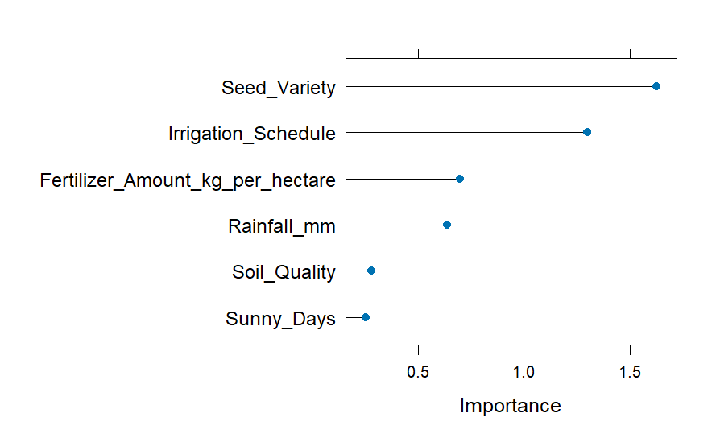

```r
lr_imp <- varImp(lrFit, scale = F, lambda=0.01)
plot(lr_imp, scales = list(y = list(cex = .95)))
```

The variable importance matches up with what we obtained previously from the ggcorr().

### The ROC curve

The ROC curve shows true positives vs false positives in relation with different thresholds:

```r
probability = predict(logit.model,as.matrix(testingCls), type='response')
roc.glm <- roc(testingCls$Yield,probability)
```

```
Warning: Deprecated use a matrix as predictor. Unexpected results may be produced, please pass a numeric vector.Setting direction: controls < cases
```

```r
auc(roc.glm)
```

```
Area under the curve: 0.9774
```

```
Warning: Deprecated use a matrix as predictor. Unexpected results may be produced, please pass a numeric vector.Setting direction: controls < cases
```

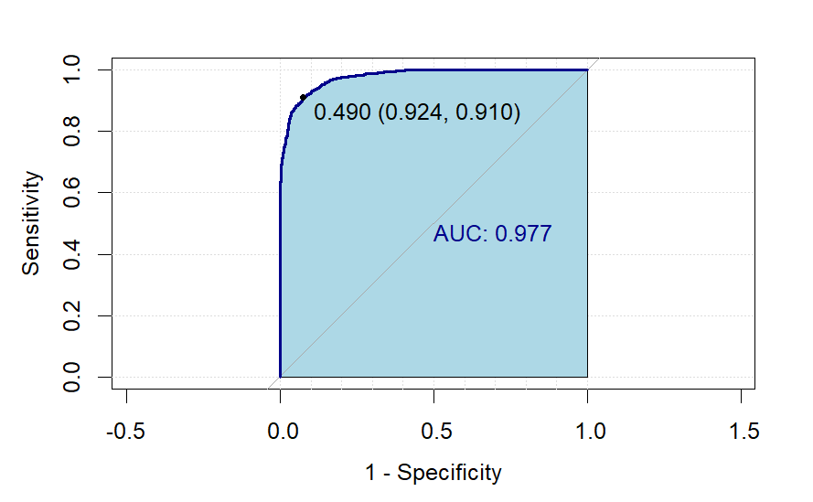

```r
plot.roc(testingCls$Yield, probability,col="darkblue", print.auc = TRUE,  auc.polygon=TRUE, grid=c(0.1, 0.2),
         # plot.roc(testing$Creditability, probability[,2],col="darkblue", print.auc = TRUE,  auc.polygon=TRUE, grid=c(0.1, 0.2), grid.col=c("green", "red"), max.auc.polygon=TRUE,
         auc.polygon.col="lightblue", print.thres=TRUE, legacy.axes = TRUE)
```

Therefore, we obtain that the optimum threshold is 0.49. We can also see that the area under the curve (AUC) is very close to 1, which is a good sign of our model. Let’s change the prediction and see the results:

```r
prediction <- as.factor(ifelse(probability > 0.49,"Low","High"))

confusionMatrix(prediction, testingCls$Yield)
```

```
Confusion Matrix and Statistics

          Reference
Prediction High  Low
      High 1800  184
      Low   149 1867

               Accuracy : 0.9168
                 95% CI : (0.9078, 0.9251)
    No Information Rate : 0.5128
    P-Value [Acc > NIR] : < 2e-16

                  Kappa : 0.8335

 Mcnemar's Test P-Value : 0.06244

            Sensitivity : 0.9236
            Specificity : 0.9103
         Pos Pred Value : 0.9073
         Neg Pred Value : 0.9261
             Prevalence : 0.4873
         Detection Rate : 0.4500
   Detection Prevalence : 0.4960
      Balanced Accuracy : 0.9169

       'Positive' Class : High
```

We get a slightly higher accuracy, the best one so far in fact.

## Economic impact

We will adjust our model taking into account that a farmer’s prediction about whether there will be a high or low yield will affect that farmer’s profit depending on the outcome (because that farmer will buy more / less fertilizer, irrigation, seeds, etc). Our objective is to maximize a farmer’s profit.

Profit matrix:

| Prediction/Reference | High yield | Low yield |
| --- | --- | --- |
| Predicted high yield | 10000 | -1000 |
| Predicted low yield | 5000 | 2000 |

Profit table as a vector:

```r
profit.unit <- c(10000, 5000, -1000, 2000)
```

What is the expected profit using our last model as a basis for predicting future yields?

```r
CM = confusionMatrix(factor(prediction), testingCls$Yield)$table
profit = sum(as.vector(CM)*profit.unit)/sum(CM)
profit
```

```
[1] 5573.75
```

### Cost-sensitive classifier

```r
profit.i = matrix(NA, nrow = 100, ncol = 10)
# 20 replicates for training/testing sets for each of the 10 values of threshold
j <- 0
for (threshold in seq(0.05,0.5,0.05)){

  j <- j + 1
  cat(j)
  for(i in 1:100){

    lrFit <- train(Yield ~ ., data=trainingCls, method = "glmnet",                    tuneGrid = data.frame(alpha = 0.3, lambda = 0), preProcess = c("center", "scale"),
                   trControl = trainControl(method = "none", classProbs = TRUE))

    lrProb = predict(lrFit, testingCls, type="prob")
    lrPred = rep("High", nrow(testingCls))
    lrPred[which(lrProb[,2] > threshold)] = "Low"
    CM = confusionMatrix(factor(lrPred), testingCls$Yield)$table
    profit = sum(as.vector(CM)*profit.unit)/sum(CM)
    profit
    profit.i[i,j] <- profit

  }
}
```

```
1
```

## Decision trees

We will try machine learning models to see if they perform better than the previous models.

```r
library(rpart)
# Hyper-parameters
control = rpart.control(minsplit = 50, maxdepth = 15, cp=0.01)
# Parameters chosen to try to maximize the accuracy
# minsplit: minimum number of observations in a node before before a split
# maxdepth: maximum depth of any node of the final tree # cp: degree of complexity, the smaller the more branches

model = Yield ~.
dtFit <- rpart(model, data=trainingCls, method = "class", control = control)
summary(dtFit)
```

[output not shown]

Visualization:

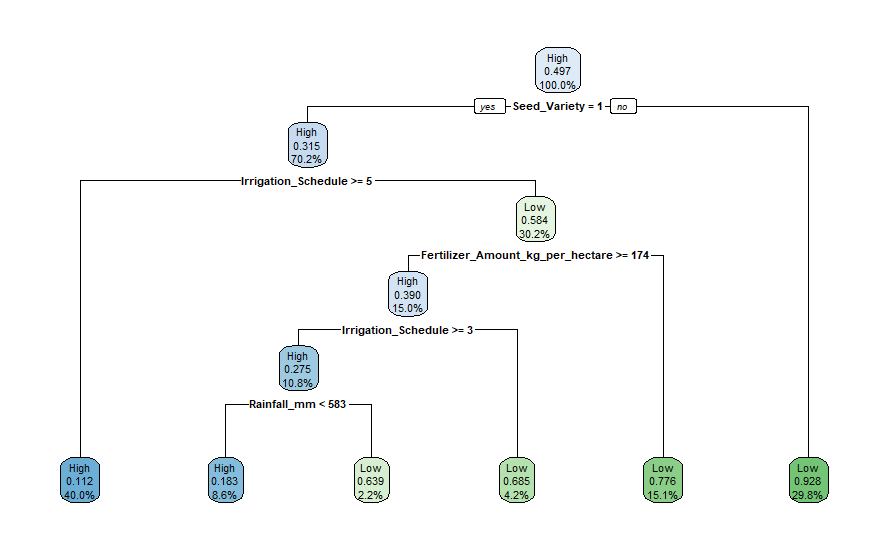

```r
library(rpart.plot)
rpart.plot(dtFit, digits=3)
```

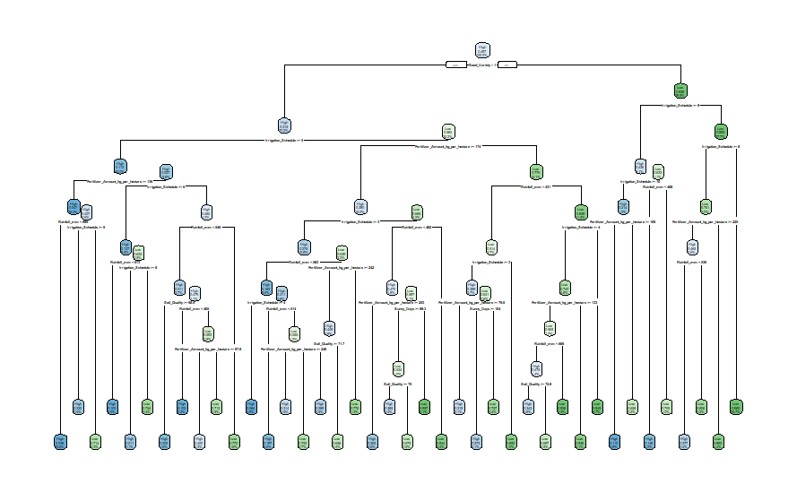

```r
control = rpart.control(minsplit = 50, maxdepth = 15, cp=0.001) # Parameters chosen to try to maximize the accuracy
dtFit <- rpart(model, data=trainingCls, method = "class", control = control)
rpart.plot(dtFit, digits = 3)
```

Prediction:

```r
dtPred <- predict(dtFit, testingCls, type = "class")
dtProb <- predict(dtFit, testingCls, type = "prob")
threshold = 0.2
dtPred = rep("High", nrow(testingCls))
dtPred[which(dtProb[,2] > threshold)] = "Low"

CM = confusionMatrix(factor(dtPred), testingCls$Yield)$table
accuracy = sum(diag(CM)) / sum(CM)
CM
```

```
          Reference
Prediction High  Low
      High 1549  133
      Low   400 1918
```

```r
accuracy
```

```
[1] 0.86675
```

The accuracy is much lower than that obtained with glm and glmnet.

### Caret

```r
library(caret)
caret.fit <- train(model, data = trainingCls,                     method = "rpart", control=rpart.control(minsplit = 50, maxdepth = 15), trControl = trainControl(method = "cv", number = 5), tuneLength=40)
# Parameters chosen to try to maximize the accuracy
caret.fit
```

Visualization:

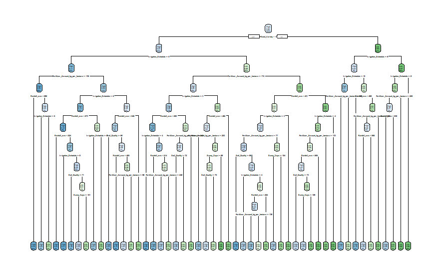

```r
rpart.plot(caret.fit$finalModel)
```

Prediction:

```r
dtProb <- predict(caret.fit, testingCls, type = "prob")
threshold = 0.49
dtPred = rep("High", nrow(testingCls))
dtPred[which(dtProb[,2] > threshold)] = "Low"
CM = confusionMatrix(factor(dtPred), testingCls$Yield)$table
accuracy = sum(diag(CM)) / sum(CM)

CM
accuracy
```

[output not shown]

### Random Forest

```r
rf.train <- randomForest(Yield ~., data=trainingCls,                      ntree=200,mtry=6,importance=TRUE, do.trace=T)

# Parameters chosen to try to maximize the accuracy
# mtry: number of variables randomly sampled as candidates at each split
# ntree: number of trees to grow
# cutoff: cutoff probabilities in majority vote
```

Prediction:

```r
rf.pred <- predict(rf.train, newdata=testingCls)
confusionMatrix(rf.pred, testingCls$Yield)
```

[output not shown]

# Advanced Regression

## Simple regression

We try first the most relevant predictor:

```r
linFit <- lm(log(Yield_kg_per_hectare) ~ Seed_Variety, data=training)
summary(linFit)
```

```
Call:
lm(formula = log(Yield_kg_per_hectare) ~ Seed_Variety, data = training)

Residuals:
     Min       1Q   Median       3Q      Max
-2.11948 -0.13159  0.01515  0.15309  0.80025

Coefficients:
             Estimate Std. Error t value Pr(>|t|)
(Intercept)  6.171525   0.003451  1788.4   <2e-16 ***
Seed_Variety 0.500209   0.004119   121.4   <2e-16 ***
---
Signif. codes:  0 ‘***’ 0.001 ‘**’ 0.01 ‘*’ 0.05 ‘.’ 0.1 ‘ ’ 1

Residual standard error: 0.2383 on 15998 degrees of freedom
Multiple R-squared:  0.4797,    Adjusted R-squared:  0.4797
F-statistic: 1.475e+04 on 1 and 15998 DF,  p-value: < 2.2e-16
```

R2 is roughly 50%, the seed variety is significant. We need to keep in mind that the seed variety only has two possible values: 0 and 1.

Predictions:

```r
pr.simple = exp(predict(linFit, newdata=testing))
cor(testing$Yield_kg_per_hectare, pr.simple)^2
```

```
[1] 0.4469056
```

## Multiple regression

```r
linFit <- lm(Yield_kg_per_hectare ~ Seed_Variety + Irrigation_Schedule + Fertilizer_Amount_kg_per_hectare + Soil_Quality + Sunny_Days + Rainfall_mm, data=training)
summary(linFit)

'
Examples of alternative models with a lower or equal R^2:

linFit <- lm(Yield_kg_per_hectare ~ Seed_Variety + Irrigation_Schedule + Fertilizer_Amount_kg_per_hectare + Soil_Quality + Sunny_Days, data=training)

linFit <- lm(log(Yield_kg_per_hectare) ~ Seed_Variety + Irrigation_Schedule + Fertilizer_Amount_kg_per_hectare + Soil_Quality + Sunny_Days + Rainfall_mm, data=training)

linFit <- lm(Yield_kg_per_hectare ~ Seed_Variety + Irrigation_Schedule + Fertilizer_Amount_kg_per_hectare + Soil_Quality + log(Sunny_Days) + Rainfall_mm, data=training)
'
```

Though using different models, we have concluded that the best linear regression model includes all variables, without using logarithms to find exponential relationships.

## Prediction

```r
predictions <- predict(linFit, newdata=testing)
cor(testing$Yield_kg_per_hectare, predictions)^2
```

```
[1] 0.9356143
```

```r
RMSE <- sqrt(mean((predictions - testing$Yield_kg_per_hectare)^2))
RMSE
```

```
[1] 50.62647
```

Now we need to try some advanced regression models: statistical learning + machine learning.

## A benchmark

We can predict all the new yield kilograms per hectare as the average yield kilograms per hectare in the training set.

```r
mean(training$Yield_kg_per_hectare)
```

```
[1] 713.9997
```

We will try the following models with different methods, to find the best regression for our data:

```r
ModelS = Yield_kg_per_hectare ~ Seed_Variety + Irrigation_Schedule + Fertilizer_Amount_kg_per_hectare + Rainfall_mm
ModelF = Yield_kg_per_hectare ~ Seed_Variety + Irrigation_Schedule + Soil_Quality + Fertilizer_Amount_kg_per_hectare + Sunny_Days + Rainfall_mm

test_results <- data.frame(Yield_kg_per_hectare = testing$Yield_kg_per_hectare)
```

## Linear regression

Training:

```r
lm_tune <- train(ModelS, data = training,
                 method = "lm",
                 preProc=c('scale', 'center'),
                 trControl = ctrl)
lm_tune
```

Prediction:

```r
test_results$lm <- predict(lm_tune, testing)
postResample(pred = test_results$lm,  obs = test_results$Yield_kg_per_hectare)
```

```
      RMSE   Rsquared        MAE
58.1182262  0.9151545 46.4641841
```

Visualization:

[figure not shown]

```r
qplot(test_results$lm, test_results$Yield_kg_per_hectare) +    labs(title="Linear Regression Observed VS Predicted", x="Predicted", y="Observed") +   lims(x = c(10, 15), y = c(10, 15)) +   geom_abline(intercept = 0, slope = 1, colour = "blue") +   theme_bw()
```

## Overfitted linear regression

Training:

```r
alm_tune <- train(ModelF, data = training,
                  method = "lm",
                  preProc=c('scale', 'center'),
                  trControl = ctrl)
```

Prediction:

```r
test_results$alm <- predict(alm_tune, testing)
postResample(pred = test_results$alm,  obs = test_results$Yield_kg_per_hectare)
```

```
      RMSE   Rsquared        MAE
50.6264684  0.9356143 40.5788546
```

As we can see, R^2 is slightly higher.

Visualization:

[figure not shown]

```r
qplot(test_results$alm, test_results$Yield_kg_per_hectare) +    labs(title="Linear Regression Observed VS Predicted", x="Predicted", y="Observed") +   lims(x = c(10, 15), y = c(10, 15)) +   geom_abline(intercept = 0, slope = 1, colour = "blue") +   theme_bw()
```

## Forward regression

```r
for_tune <- train(ModelF, data = training,
                  method = "leapForward",
                  preProc=c('scale', 'center'),
                  tuneGrid = expand.grid(nvmax = 4),
                  trControl = ctrl)
for_tune
```

Which variables are selected?

```r
coef(for_tune$finalModel, for_tune$bestTune$nvmax)
```

```
                     (Intercept)                     Seed_Variety
                       713.99973                        137.30506
             Irrigation_Schedule Fertilizer_Amount_kg_per_hectare
                       111.66356                         58.18627
                     Rainfall_mm
                       -50.52873
```

The variables that are selected are those from ModelS.

Prediction:

```r
test_results$frw <- predict(for_tune, testing)
postResample(pred = test_results$frw,  obs = test_results$Yield_kg_per_hectare)
```

```
      RMSE   Rsquared        MAE
58.1182262  0.9151545 46.4641841
```

Visualization:

[figure not shown]

```r
qplot(test_results$frw, test_results$Yield_kg_per_hectare) +    labs(title="Forward Regression Observed VS Predicted", x="Predicted", y="Observed") +   lims(x = c(10, 15), y = c(10, 15)) +   geom_abline(intercept = 0, slope = 1, colour = "blue") +   theme_bw()
```

## Backward regression

Training:

```r
back_tune <- train(ModelF, data = training,
                   method = "leapBackward",
                   preProc=c('scale', 'center'),
                   tuneGrid = expand.grid(nvmax = 4),
                   trControl = ctrl)
back_tune
```

Which variables are selected?

```r
coef(back_tune$finalModel, back_tune$bestTune$nvmax)
```

```
                     (Intercept)                     Seed_Variety
                       713.99973                        137.30506
             Irrigation_Schedule Fertilizer_Amount_kg_per_hectare
                       111.66356                         58.18627
                     Rainfall_mm
                       -50.52873
```

Prediction:

```r
test_results$bw <- predict(back_tune, testing)
postResample(pred = test_results$bw,
             obs = test_results$Yield_kg_per_hectare)
```

```
      RMSE   Rsquared        MAE
58.1182262  0.9151545 46.4641841
```

Visualization:

[figure not shown]

```r
qplot(test_results$bw, test_results$Yield_kg_per_hectare) +    labs(title="Backward Regression Observed VS Predicted", x="Predicted", y="Observed") +   lims(x = c(10, 15), y = c(10, 15)) +   geom_abline(intercept = 0, slope = 1, colour = "blue") +   theme_bw()
```

## Stepwise regression

```r
step_tune <- train(ModelF, data = training,                     method = "leapSeq",                     preProc=c('scale', 'center'),                    tuneGrid = expand.grid(nvmax = 4),                    trControl = ctrl)
# which variables are selected?
coef(step_tune$finalModel, step_tune$bestTune$nvmax)
```

```
                     (Intercept)                     Seed_Variety
                       713.99973                        137.30506
             Irrigation_Schedule Fertilizer_Amount_kg_per_hectare
                       111.66356                         58.18627
                     Rainfall_mm
                       -50.52873
```

```r
test_results$seq <- predict(step_tune, testing)
postResample(pred = test_results$seq,  obs = test_results$Yield_kg_per_hectare)
```

```
      RMSE   Rsquared        MAE
58.1182262  0.9151545 46.4641841
```

## Ridge regression

Let’s use first the original glmnet package.

### glmnet

The package, written originally in Fortran, does not allow for R formulas, hence we need to transform a model into a matrix format.

```r
library(glmnet)

# X matrix
X = model.matrix(ModelF, data=training)[,-1]  # skip column of ones

# y variable
y = training$Yield_kg_per_hectare
```

Now we need to define a grid for the penalty hyper-parameter lambda.

```r
grid = seq(0, .1, length = 100)  # a 100-size grid for lambda (rho in slides)
```

We estimate the ridge regression for all the penalties defined in the grid. The algorithm is extremely fast.

```r
ridge.mod = glmnet(X, y, alpha=0, lambda=grid)  # alpha=0 for ridge regression
```

Ridge regression is shrinking only beta’s associated with variables, not $\beta_0$.

```r
dim(coef(ridge.mod))
```

```
[1]   7 100
```

```r
coef(ridge.mod)
```

```
7 x 100 sparse Matrix of class "dgCMatrix"
```

```
  [[ suppressing 100 column names ‘s0’, ‘s1’, ‘s2’ ... ]]
```

[output not shown]

[output cut: 144 more lines]

[output not shown]

Solution path:

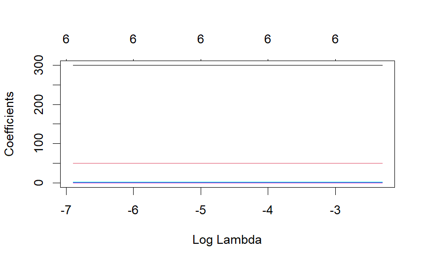

```r
plot(ridge.mod, xvar="lambda")
```

How do we select the optimal hyper-parameter?

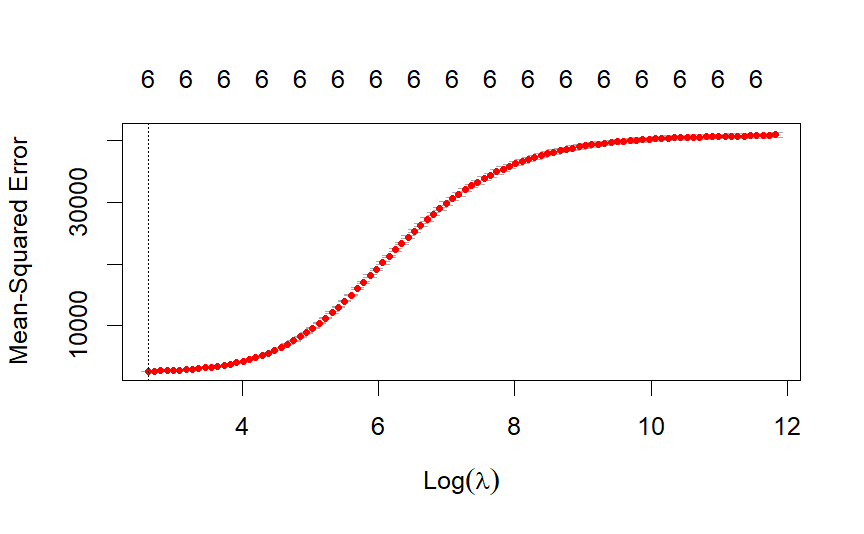

```r
ridge.cv = cv.glmnet(X, y, type.measure="mse", alpha=0)
plot(ridge.cv)
```

The lowest point in the curve indicates the optimal lambda: the log value of lambda that best minimised the error in cross-validation.

```r
opt.lambda <- ridge.cv$lambda.min
opt.lambda
```

```
[1] 13.7539
```

lambda.1se is recommended to estimate the betas.

```r
lambda.index <- which(ridge.cv$lambda == ridge.cv$lambda.1se)
beta.ridge <- ridge.cv$glmnet.fit$beta[, lambda.index]
beta.ridge
```

```
                    Seed_Variety              Irrigation_Schedule
                     281.3399256                       46.8588729
                    Soil_Quality Fertilizer_Amount_kg_per_hectare
                       1.4439985                        0.7567707
                      Sunny_Days                      Rainfall_mm
                       1.8665936                       -0.4735693
```

Prediction:

```r
X.test = model.matrix(ModelF, data=testing)[,-1]  # skip column of ones

ridge.pred = predict(ridge.cv$glmnet.fit, s=opt.lambda, newx=X.test)
```

To visualize the performance, we can use the postResample function in caret.

```r
y.test = testing$Yield_kg_per_hectare
postResample(pred = ridge.pred,  obs = y.test)
```

```
      RMSE   Rsquared        MAE
51.8569112  0.9356189 41.4899450
```

Let’s do it now with caret.

### caret

```r
# the grid for lambda
ridge_grid <- expand.grid(lambda = seq(0, .1, length = 100))

# train
ridge_tune <- train(ModelF, data = training,
                    method='ridge',
                    preProc=c('scale','center'),
                    tuneGrid = ridge_grid,
                    trControl=ctrl)

# the best tune
ridge_tune$bestTune

# prediction
test_results$ridge <- predict(ridge_tune, testing)

postResample(pred = test_results$ridge,  obs = test_results$Yield_kg_per_hectare)
```

[output not shown]

Therefore, we have found that the best regression model (the one with the highest R^2) involves tuning hyper parameters with glmnet.

# Conclusion

In conclusion, we have found that both in the classification and in the linear regression, the best model uses glmnet while tuning the hyperparameters (the threshold in the classification and lambda in the linear regression). In fact, we have used those models to achieve impressive results capable of predicting the yield based on the rest of the variables, whch could be used by farmers to maximize their profits.

# Bibliography

- AirlineDelaysCaseStudyIntro_Solution.Rmd, from Aula Global
- 2023.CreditScoringCaseStudy.Rmd, from Aula Global
- CustomerChurnCaseStudy_Solution.Rmd, from Aula Global
- HousePricingCaseStudy_Students.Rmd, from Aula Global